# In memoriam

## Lewiatan

W historii myśli politycznej jedną z najbardziej znanych metafor państwa jest wymyślona przez Thomasa Hobbesa **figura Lewiatana**, ogromnego potwora gotowego pożreć wszystko, co stoi mu na drodze. Potworem jest państwo, a jego żarłem - obszary wolności, w których porusza(ł) się poddany Lewiatana. A ściślej: jedynym słusznym wyborem poddanego jest poddanie się władzy Lewiatana.

[figure not shown]

Tytułowy potwór na okładce *Lewiatana* ofiarowanej królowi Karolowi II. 1651 Źródło: https://commons.wikimedia.org/wiki/File:Drawing_of_frontispiece_of_Leviathan.jpg

Może Lewiatan kiedyś był tylko efektowną metaforą, działającą na wyobraźnie studentów ówczesnych uniwersytetów. Dzisiaj jednak obserwując zapędy ustawodawcy, można stwierdzić, że omawiana przenośnia stała się rzeczywistością: w zbiurokratyzowanych czasach widzimy, jak machina państwowa wywłaszcza z prywatnej sfery coraz więcej spraw i zaczyna je regulować milionem przepisów.

Tyczy się to oczywiście podatków i danin, które obciążają wielość zdarzeń – od sprzedaży chleba przez zbycie samochodu po zjedzenie schabowego na rodzinnym pikniku organizowanym przez Twojego szefa.

Lewiatan pożera coraz więcej zdarzeń prawnych. Nie mogąc ich wszystkich przetrawić, zaczyna cierpieć w pewnym momencie na niestrawność – jego układ trawienny ma swoje moce przerobowe. Wiele mówi się o nadprodukcji prawa przez Panie i Panów z Sejmu - ale nie o tej przypadłości mowa.

Prawdziwa niestrawność dotyka obszaru stosowania prawa, a w szczególności jego wykładni (interpretacji). Nasz polski Lewiatan cierpi na **biegunkę interpretacyjną** – a jej przejawem jest prawie **350.000 interpretacji podatkowych** wydanych na przestrzeni ostatnich kilkunastu lat. Interpretacje podatkowe są właśnie symptomem pewnej choroby, ale w dosyć pokrętnym sensie. Miały bowiem stanowić lekarstwo na niejednoznaczność przepisów i wypływającą z niej samowolę urzędników w interpretowaniu prawa podatkowego.

I tak jak liczba sprzedawanych leków świadczy o zwiększonym odsetku chorych ludzi, tak i liczba interpretacji indywidualnych świadczy o problemach społeczeństwa z prawem podatkowym.

## Interpretacje podatkowe - krótki wstęp

Indywidualna interpretacja przepisów prawa podatkowego („interpretacja podatkowa”, "interpretacja", "interpretacja indywidualna") jest wydawana przez organ podatkowy na wniosek podatnika i chroni go w następujący sposób:

*Jeśli **podatnik będzie postępował dokładnie tak, jak organ określi w wydanej dla podatnika interpretacji** – w razie przyszłej ewentualnej kontroli podatkowej, **organy państwa nie będą mogły zinterpretować prawa w inny sposób, jak określony w interpretacji**.*

Podatnik jest obowiązany we wniosku o wydanie interpretacji do pełnej prezentacji stanu faktycznego (zdarzenia przyszłego) i zadaje pytanie prawne. Przedstawia również swoje stanowisko (interpretację), jakie przepisy i w jaki sposób powinny zadziałać w jego sytuacji.

Interpretacja indywidualna przypomina klasyczny model stosowania prawa (subsumpcja), co przedstawiłem poniżej w tabelce (przypomina, ponieważ subsumpcja dotyczy tylko bardziej wiążących aktów prawnych, jak decyzje czy wyroki).

*Przykładowy problem i przykładowa interpretacja*

| Krok | Model | Przykład |
| --- | --- | --- |
| 1 | Organ ma ustalić, jakie normy prawne powinny obowiązywać w sytuacji opisanej przez podatnika. | Polski podatnik płaci podatek od darowizny. Jeśli podatnik uzyskuje darowiznę od rodzica, to darowizna nie podlega opodatkowaniu do 9637 PLN. |
| 2 | Następnie musi ująć dany stan faktyczny w pojęciach normy („nazwać” poszczególne elementy fachowymi nazwami wziętymi wprost z przepisu prawnego). | Mama Kowalskiego [Rodzic] dała Kowalskiemu [polskiemu podatnikowi] 7000 PLN [darowiznę w wysokości 7000 PLN]. |
| 3 | Po analizie dokonanej w Kroku 1 i 2 organ może wreszcie stwierdzić, że stan faktyczny rzeczywiście podlega (nie podlega) normie prawnej. | Kowalski nie podlega opodatkowaniu. |
| 4 | I na samym końcu stwierdzić, jakie konsekwencje prawne wiążą się z podleganiem / niepodleganiem normie prawnej. | Kowalski nie płaci podatku. |

Podatnik po uzyskaniu interpretacji ma trzy wyjścia:

1. zastosować się do niej – wtedy jego działania są chronione interpretacją,
2. nie zastosować się; w razie ewentualnej kontroli dalej może spierać się z organem i dalej może kwestionować zdanie organu przed sądem;
3. zaskarżyć negatywną interpretację przed sądem administracyjnym.

Trzeba też wspomnieć, że bardzo istotny jest **rzetelny opis sytuacji (teraźniejszej lub przyszłej) będącej przedmiotem interpretacji**. Jeśli podatnik nie poda w wyczerpujący sposób wszystkich elementów stanu faktycznego (zdarzenia przyszłego), wobec której mają zostać zastosowane normy prawa podatkowego, **jedyną sankcją**, jaka go spotka, będzie w zasadzie brak możliwości skorzystania z „zabezpieczającego” charakteru interpretacji podatkowej.

Schemat wygląda przejrzyście w tabelce, ale w rzeczywistości sam proces wykładni prawa jest **skomplikowany** i nie tylko dlatego, że składa się na nią zespół reguł wypracowanych przez mecenasów i profesorów prawa: sądy i organy dowolnie wykorzystują te niepisane reguły, czego przykładów dostarcza [prasa](https://www.money.pl/gospodarka/wiadomosci/artykul/podatkowy-absurd-opinia-skarbowki-podatki,95,0,2400351.html).

W tym niewielkim eseju pokażę, w jaki sposób można uchwycić tendencje zmian w tematyce interpretacji na przestrzeni lat i jak jedna zmiana prawna mogła (prawdopodobnie) odstraszyć podatników od wnioskowania o tę swoistą tarczę podatkową.

## Intepretacje podatkowe w liczbach

W mojej bazie danych mam 341756 interpretacji ściągniętych od dnia 24 lipca 2007 roku do dnia 26 września 2018 roku (o tym jak je klasyfikowałem przeczytaj [tutaj](https://github.com/ArturTan/aleteior/blob/master/inmemoriam/PS.ipynb)). Autorami interpretacji są przede wszystkim organy krajowe: Dyrektorzy dawnych Izb Skarbowych oraz Dyrektor Krajowej Informacji Podatkowej (od 2017 r.). W eseju nie analizuję interpretacji lokalnych (wydawanych przez wójtów, burmistrzów czy prezydentów miast).

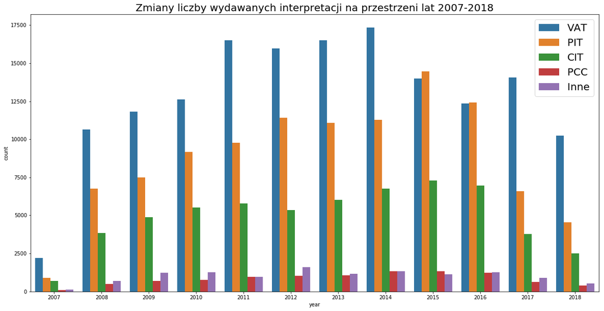

```python
import inmemoriam_scripts
from inmemoriam_scripts.utilities import colorize

%matplotlib inline
inmemoriam_scripts.tax_across_years()
```

```python
inmemoriam_scripts.show_changes_across_years().\
           style.applymap(inmemoriam_scripts.colorize.colorize)
```

| year | 2009 | 2010 | 2011 | 2012 | 2013 | 2014 | 2015 | 2016 | 2017 |
| --- | --- | --- | --- | --- | --- | --- | --- | --- | --- |
| VAT | 11.14 | 6.71 | 30.81 | -3.22 | 3.51 | 4.97 | -19.39 | -11.69 | 13.83 |
| PIT | 11.1 | 21.99 | 6.75 | 16.73 | -2.81 | 1.57 | 28.41 | -14.13 | -47.03 |
| CIT | 27.14 | 13.22 | 4.63 | -7.45 | 12.38 | 12.11 | 8.05 | -4.73 | -45.85 |
| PCC | 41.35 | 6.61 | 29.42 | 6.52 | 2.78 | 22.91 | 0.3 | -6.19 | -49.28 |
| Inne | 80.18 | 3.83 | -23 | 64.22 | -27.62 | 14.41 | -14.24 | 11.8 | -29.55 |

*Zmiany procentowe wydawanych interpretacji [w odniesieniu do roku poprzedzającego]*

## GAAR a sprawa PIT-owska

Jak widać większość interpretacji dotyczy VAT, co raczej nie powinno dziwić: w **zasadzie każda transakcja jest ovatowana**, a obowiązek zapłaty VAT jest jednym z najbardziej uciążliwych i czasochłonnych (comiesięczne deklaracje). Przedsiębiorcy chcą upewnić się, jaka stawka podatku obejmuje świadczone przez nich usługi lub sprzedawane towary.

Drugie w klasyfikacji pod względem liczebności są podatki dochodowe **PIT (od osób fizycznych) oraz CIT (od osób prawnych)**, czyli podatki, które podatnicy płacą raz w roku (co do zasady).

Widać również wzrastającą tendencję pomiędzy latami 2009 i 2015 oraz nagłe jej załamanie, którego pierwszym rokiem jest 2016 (zmniejszenie liczby wydawanych interpretacji PIT-owskich i CIT-owskich), a tendencja spadkowa trwa do 2017&nbspr.

Dlaczego podatnicy przestali wnioskować o interpretacje w 2016 r.?

Nie będziemy czytać wszystkich interpretacji, aby spróbować odpowiedzieć na to pytanie. Można dokonać analizy najczęściej występujących słów w interpretacjach PIT-owskich.

Teksty poszczególnych interpretacji podzieliłem na tokeny, a następnie na lematy za pomocą biblioteki Morfeusz (o czym **możesz poczytać**[tutaj](https://github.com/ArturTan/aleteior/blob/master/inmemoriam/PS.ipynb)). Dla potrzeb niniejszego tekstu przez lemat rozumiem najbardziej podstawową formę danego wyrazu (więcej o tokenach [tutaj](https://en.wikipedia.org/wiki/Lexical_analysis), a o lematach [tutaj](http://sgjp.pl/morfeusz/morfeusz.html.po)).

W analizie będziemy się starać wyeliminować najczęściej występujące słowa, które nie będą niosły ze sobą zbyt dużego ładunku znaczeniowego (takie jak spójniki, niektóre często występujące czasowniki). **Usuniemy** również te słowa, które są charakterystyczne dla samego języka prawniczego / urzędniczego używanego w interpretacjach o PIT ("interpretacja", "podatek", "prawo", "prawny", "dochodowy") oraz pewne nalecialości, które nie zostały wyłapane przez algorytm Morfeusza.

Do agregacji użyjemy algorytmu TF-IDF (ang. *term frequency-inverse document frequency*). Pozwala on na osiągnięcie bardzo ważnej rzeczy: możemy wyodrębnić z danego dokumentu takie słowa, które świadczą o swoistości (indywidualności) tego dokumentu **względem** całego korpusu dokumentów (przeczytaj o tym [tutaj](http://scikit-learn.org/stable/modules/feature_extraction.html#text-feature-extraction)).

Działa to w następujący sposób:

1. liczymy częstotliwość występowania słowa W dla danego dokumentu [TF(W)],
2. liczymy częstotliwość występowania słowa W dla całego korpusu - [DF(W)] i "odwracamy" ją według wzoru:

   \(IDF(W) = \log\frac{1 + n_d}{1 + DF(W)} + 1\)

   gdzie \(n_d\) oznacza liczbę wszystkich dokumentów w korpusie.
3. waga dla danego słowa w danym dokumencie wynosi TF(W) x IDF(W), przy czym jest ona dodatkowo normalizowana po uzyskaniu wszystkich wartości.

Powyższy algorytm zastosujemy odnośnie trzech lat (2015, 2016, 2017) dla interpretacji indywidualnych z zakresu PIT. Następnie wybierzemy dla każdej interpretacji 100 słów najbardziej dla niej charakterystycznych (czyli 100 słów z największą wartością TF-IDF). Na samym końcu policzymy, jak często dane słowa są najbardziej charakterystyczne dla interpretacji wydanych w konkretnym roku.

Porównajmy lata 2015 i 2016 na wykresie punktowym (ang. *scatter plot*).

```python
data_to_plot = inmemoriam_scripts.read_tax_data_vectorizer_results(
                                                "data/data_2015.csv",
                                                "data/data_2016.csv",
                                                "data/data_2017.csv",
                                                ["2015", "2016", "2017"])
```

```python
data_to_plot_2015_2016 = inmemoriam_scripts.select_two_years_for_comparison("2015",
                                                                            "2016",
                                                                            data_to_plot)

tax_data_for_2015_2016_in_scatterplot = inmemoriam_scripts.TaxDataInScatterPlot(data_to_plot_2015_2016)
tax_data_for_2015_2016_in_scatterplot.get_frequencies()
tax_data_for_2015_2016_in_scatterplot.create_html_with_two_categories("2016", "2015", 'scatter_plots_html/2015_2016_PIT.html')
#tax_data_for_2015_2016_in_scatterplot.take_screenshoot("pics/2015_2016.png")
```

[figure not shown]

*Najbardziej charakterystyczne słowa dla interpretacji PIT z roku 2015 i 2016 (powyżej)*

Biblioteka scattertext pozwala na zaprezentowanie w formie strony internetowej najbardziej charakterystycznych słów ([link](https://aleteior.pl/inmemoriam/scatter_plots_html/2015_2016_PIT.html) - wczytuje się dość długo, ale warto poczekać). Z diagramu możemy odczytać dwie rzeczy. Po pierwsze, frekwencję danego wyrazu dla obydwu porównywanych lat. **Jednak sama częstotliwość to wciąż za mało**, aby wysnuć pewniejsze wnioski.

Po drugie, diagram prezentuje bardziej interesującą miarę f-score (po podświetleniu słowa pojawia się chmurka pokazująca tę miarę dla roku 2016). **Im wyższy** wskaźnik f-score, **tym bardziej** słowo wiąże się z rokiem 2016 (wartości jest bliżej do 1,0). **Im niższy** wskaźnik f-score, **tym bardziej** dane słowo wiąże się z rokiem 2015 (wartości jest bliżej do 0,0). Konsekwentnie wartości w okolicach 0,5 świadczą o tym, że interpretacje o danej tematyce pojawiają się równie często wśród interpretacji roku 2015, jak i 2016.

Przypatrzmy się zatem f-score właściwemu dla lat 2016 oraz 2015 (**UWAGA**: wybrałem wyrazy ze wskaźnikiem f-score większym od 0,9 lub mniejszym od 0,1):

```python
tax_data_for_2015_2016_in_scatterplot.present_fscores("2016", "2015")
```

| Najbardziej charakterystyczne słowa dla 2016 r. | fscore |
| --- | --- |
| 2016 | 1 |
| odejście | 0.987122 |
| odejść | 0.979735 |
| rekompensata | 0.979325 |
| zabezpieczający | 0.977885 |
| skrócić | 0.963385 |
| zadośćuczynienie | 0.962256 |
| zadośćuczynić | 0.962192 |
| porozumieć | 0.961915 |
| wprost | 0.961748 |
| poszkodować | 0.96089 |
| porozumienie | 0.960257 |
| ustawić | 0.958705 |
| poszkodowany | 0.95827 |
| regulamin | 0.95746 |
| zbiorowy | 0.955913 |
| odprawa | 0.955792 |
| szkoda | 0.954756 |
| zastosować | 0.951803 |
| wykonawczy | 0.948616 |
| odszkodowanie | 0.94808 |
| odszkodować | 0.948022 |
| zastosowanie | 0.947139 |
| pracowniczy | 0.946832 |
| niemajątkowy | 0.946562 |
| gwarancja | 0.944784 |
| ulga | 0.94408 |
| rozwiązywać | 0.943912 |
| metoda | 0.942762 |
| uszczerbek | 0.942755 |

[output cut: 79 more lines]

| Najbardziej charakterystyczne słowa dla 2015 r. | fscore |
| --- | --- |
| 2014 | 0 |
| 2015 | 0.00756171 |
| obowiązujący | 0.0116467 |
| pochodzić | 0.0132942 |
| obrotowy | 0.0176674 |
| pisemny | 0.0192576 |
| brzmieć | 0.0193611 |
| jawny | 0.0223276 |
| likwidacja | 0.0225851 |
| zobowiązanie | 0.0229767 |
| przekształcenie | 0.023305 |
| brzmienie | 0.0241104 |
| przekształcić | 0.0263002 |
| 14 | 0.0307271 |
| akcyjny | 0.0318962 |
| wypracować | 0.0322165 |
| powstanie | 0.0328125 |
| zobowiązać | 0.0337419 |
| ska | 0.034328 |
| podzielić | 0.0354578 |
| konfuzja | 0.0361196 |
| sukcesja | 0.0363296 |
| bieżący | 0.0363365 |
| powstać | 0.0369633 |
| ii | 0.0380463 |
| zgromadzić | 0.0383284 |
| dziennik_ustaw | 0.0384401 |
| upadłość | 0.0385668 |
| następujący | 0.0430122 |
| dywidenda | 0.0434818 |

[output cut: 209 more lines]

Lista powyższych słów nie ma żadnego znaczenia dla laika. Natomiast dla osoby zajmującej się interpretacjami indywidualnymi, widoczne są dwie grupy:

Słowa z grupy 2 można kategoryzować bardziej szczegółowo.

**Charakterystyczne słowa w interpretacjach indywidualnych (PIT) w roku 2016:**

['odejście', 'odejść', 'nominalny', 'ulga', 'centrum', 'porozumieć', 'porozumienie', 'przedsiębiorstwo', 'zabezpieczający', 'umawiać', 'gwarancja', 'transport', 'umowa', 'wynagrodzenie', 'wynagrodzić', 'zamieszkać', 'zadośćuczynienie', 'zadośćuczynić', 'szkoda', 'odszkodowanie', 'poszkodowany', 'powszechność', 'uszczerbek', 'krzywda', 'zbiorowy', 'regulamin', 'dobrowolny', 'kodeks', 'pracowniczy', 'odprawa', 'program', 'praca', 'pracodawca', 'zatrudnić', 'zatrudniony', 'najemny', 'pracownik']

**Charakterystyczne słowa w interpretacjach indywidualnych (PIT) w roku 2015:**

['produkcja', 'rolny', 'pozarolniczy', 'rachunkowość', 'handlowy', 'źródło', 'europejski', 'budynek', 'lokal', 'grunt', 'mieszkalny', 'uprawniony', 'majątek', 'nieruchomość', 'jawny', 'likwidacja', 'przekształcenie', 'przekształcić', 'obrotowy', 'akcyjny', 'umorzyć', 'wynik', 'zgromadzić', 'sukcesja', 'zysk', 'ska', 'wypracować', 'akt', 'uczestnictwo', 'wspólnik', 'środki', 'dywidenda', 'osobowy', 'przekształcać', 'konfuzja', 'składnik', 'spółka', 'kapitałowy', 'zbyt', 'akcja', 'zbyć', 'zbycie', 'równy', 'upadłość', 'rozwiązanie', 'komandytowy', 'rozwiązać', 'udział', 'przekazać', 'spółdzielnia', 'sa', 'kapitała', 'zobowiązanie', 'wierzytelność', 'pożyczka', 'odpłatny', 'nieodpłatny', 'należność', 'sprzedaż', 'wygaśnięcie']

Powyższe oznacza, że interpretacje podatkowe w 2015 r. częściej (w porównaniu z rokiem 2016 r.) **dotyczyły szeroko pojętych transakcji w obrębie prawa handlowego** (M&A - ang. *Merge and Acquisition*). Natomiast interpretacje indywidualne charakterystyczne dla 2016 r. dotyczyły stosunków pracy ("pracowniczy", "odprawa") oraz deliktów prawa cywilnego ("zadośćuczynienie","krzywda'). Przypatrzmy się, jak zmieniła sie "waga" danych słów na przestrzeni lat 2015-2016.

```python
from inmemoriam_scripts import TaxDataNormalizer as TaxDataNormalizer

important_tax_words_for_2015_and_2016 = inmemoriam_scripts.ImportantTaxWordsImporter("data/words_2015_2016.pkl")


normalized_data_for_lower_score = inmemoriam_scripts.TaxDataNormalizer(
                                          data_to_plot_2015_2016,
                                          (important_tax_words_for_2015_and_2016
                                               .words_lower_fscore),
                                          "2016",
                                          "2015"
                                          ).normalize()
(normalized_data_for_lower_score.sort_values(by="zmiana \"charakterystyczności\" danego słowa [w %]",
                                             ascending=True)
                                            .style.applymap(colorize.colorize))
```

|  | 2015 | 2016 | zmiana "charakterystyczności" danego słowa [w %] |
| --- | --- | --- | --- |
| konfuzja | 0.0619429 | 0.0255005 | -58.8323 |
| ska | 0.0645645 | 0.0278602 | -56.8489 |
| wygaśnięcie | 0.0590967 | 0.0267945 | -54.6598 |
| wypracować | 0.0683844 | 0.0311334 | -54.4729 |
| obrotowy | 0.0922028 | 0.0438456 | -52.4466 |
| jawny | 0.223953 | 0.115628 | -48.3698 |
| zobowiązanie | 0.111752 | 0.0577757 | -48.3 |
| likwidacja | 0.197363 | 0.102154 | -48.2406 |
| przekształcenie | 0.209872 | 0.109386 | -47.8798 |
| przekształcić | 0.209273 | 0.112202 | -46.3847 |
| upadłość | 0.0789454 | 0.0433128 | -45.1358 |
| rachunkowość | 0.0725788 | 0.0401157 | -44.7281 |
| sukcesja | 0.0844132 | 0.0468143 | -44.5414 |
| akcyjny | 0.142311 | 0.0802314 | -43.6227 |
| zgromadzić | 0.0865853 | 0.0493263 | -43.0315 |
| dywidenda | 0.0865853 | 0.0515338 | -40.482 |
| przekształcać | 0.0869598 | 0.053513 | -38.4624 |
| pożyczka | 0.136769 | 0.0849509 | -37.8872 |
| wierzytelność | 0.180211 | 0.112507 | -37.5696 |
| umorzyć | 0.112651 | 0.0704879 | -37.4279 |
| uczestnictwo | 0.108906 | 0.0700312 | -35.6956 |
| wynik | 0.309415 | 0.204156 | -34.0187 |
| produkcja | 0.101491 | 0.067367 | -33.6224 |
| zysk | 0.282526 | 0.191977 | -32.0498 |
| wspólnik | 0.35855 | 0.251047 | -29.9828 |
| równy | 0.0868849 | 0.0612773 | -29.473 |
| osobowy | 0.310988 | 0.220598 | -29.0653 |
| środki | 0.19212 | 0.137779 | -28.2852 |
| rolny | 0.129653 | 0.0934764 | -27.9027 |
| akt | 0.179387 | 0.131689 | -26.5895 |
| pozarolniczy | 0.191222 | 0.140824 | -26.3558 |
| handlowy | 0.221706 | 0.163508 | -26.2503 |
| składnik | 0.142461 | 0.106036 | -25.5683 |
| źródło | 0.154895 | 0.115551 | -25.4 |
| przekazać | 0.0865853 | 0.0647789 | -25.1849 |
| zbyt | 0.18905 | 0.143945 | -23.8588 |
| odpłatny | 0.416373 | 0.317272 | -23.8011 |
| kapitałowy | 0.232267 | 0.178275 | -23.2457 |
| sa | 0.0908546 | 0.069879 | -23.087 |
| akcja | 0.239533 | 0.184365 | -23.0315 |
| należność | 0.138716 | 0.108168 | -22.0223 |
| spółka | 0.590592 | 0.463576 | -21.5066 |
| zbyć | 0.395925 | 0.3124 | -21.0962 |
| nieodpłatny | 0.210321 | 0.166476 | -20.8467 |
| zbycie | 0.392255 | 0.310573 | -20.8237 |
| grunt | 0.141862 | 0.112354 | -20.8002 |
| sprzedaż | 0.395776 | 0.314075 | -20.6432 |
| europejski | 0.112276 | 0.0903555 | -19.5239 |
| mieszkalny | 0.146131 | 0.118216 | -19.1031 |
| rozwiązanie | 0.153172 | 0.124534 | -18.6968 |
| spółdzielnia | 0.0897311 | 0.0731522 | -18.4762 |
| komandytowy | 0.205453 | 0.167694 | -18.3782 |
| budynek | 0.131151 | 0.10733 | -18.1628 |
| kapitała | 0.0939255 | 0.0771105 | -17.9026 |
| lokal | 0.161486 | 0.132907 | -17.6975 |
| udział | 0.424987 | 0.352668 | -17.0167 |
| rozwiązać | 0.151899 | 0.127122 | -16.3114 |
| majątek | 0.385215 | 0.327624 | -14.9502 |
| nieruchomość | 0.305895 | 0.260638 | -14.7949 |
| uprawniony | 0.119617 | 0.109157 | -8.74392 |

```python
normalized_data_for_greater_score = TaxDataNormalizer(
                                       data_to_plot_2015_2016,
                                       (important_tax_words_for_2015_and_2016
                                           .words_greater_fscore),
                                       "2016",
                                       "2015").normalize()
(normalized_data_for_greater_score.sort_values(by="zmiana \"charakterystyczności\" danego słowa [w %]",
                                               ascending=True)
                                               .style.applymap(colorize.colorize))
```

|  | 2015 | 2016 | zmiana "charakterystyczności" danego słowa [w %] |
| --- | --- | --- | --- |
| umowa | 0.351434 | 0.366522 | 4.29317 |
| zamieszkać | 0.148229 | 0.15483 | 4.45344 |
| wynagrodzić | 0.154071 | 0.163888 | 6.372 |
| wynagrodzenie | 0.154296 | 0.164802 | 6.80911 |
| pracownik | 0.152348 | 0.162899 | 6.92529 |
| nominalny | 0.086061 | 0.0959884 | 11.5354 |
| zatrudniony | 0.086061 | 0.101621 | 18.0807 |
| pracodawca | 0.119691 | 0.148588 | 24.1425 |
| praca | 0.208898 | 0.261627 | 25.2416 |
| umawiać | 0.0571493 | 0.0743701 | 30.1331 |
| przedsiębiorstwo | 0.0728035 | 0.101393 | 39.2694 |
| program | 0.0924275 | 0.129405 | 40.0075 |
| zatrudnić | 0.0534042 | 0.0754358 | 41.2543 |
| kodeks | 0.0743765 | 0.106265 | 42.8742 |
| centrum | 0.046813 | 0.0727716 | 55.4517 |
| dobrowolny | 0.0659876 | 0.105199 | 59.4225 |
| powszechność | 0.0506329 | 0.0820583 | 62.0652 |
| odszkodowanie | 0.0643397 | 0.110984 | 72.4972 |
| pracowniczy | 0.0447907 | 0.0792418 | 76.916 |
| ulga | 0.0367763 | 0.0681282 | 85.2504 |
| szkoda | 0.0516066 | 0.0973586 | 88.6553 |
| zbiorowy | 0.0450154 | 0.0874629 | 94.2957 |
| regulamin | 0.0429181 | 0.085636 | 99.5334 |
| porozumienie | 0.0389484 | 0.0820583 | 110.685 |
| zadośćuczynić | 0.0421691 | 0.0895182 | 112.284 |
| zadośćuczynienie | 0.0421691 | 0.0895943 | 112.464 |
| porozumieć | 0.0376002 | 0.0815255 | 116.822 |
| odprawa | 0.0307093 | 0.0679759 | 121.353 |
| poszkodowany | 0.0272639 | 0.0656923 | 140.95 |
| uszczerbek | 0.021122 | 0.0542742 | 156.956 |
| gwarancja | 0.0175268 | 0.0525234 | 199.675 |
| najemny | 0.0128829 | 0.0465099 | 261.019 |
| odejść | 0.0185754 | 0.069879 | 276.191 |
| transport | 0.0118343 | 0.0451397 | 281.43 |
| odejście | 0.010561 | 0.0666058 | 530.676 |
| zabezpieczający | 0.00344543 | 0.0561772 | 1530.48 |
| krzywda | 0.00239682 | 0.0438456 | 1729.32 |

Skąd takie zmiany? Przyjrzyjmy się teraz, w którym momencie nastąpił **przełom**.

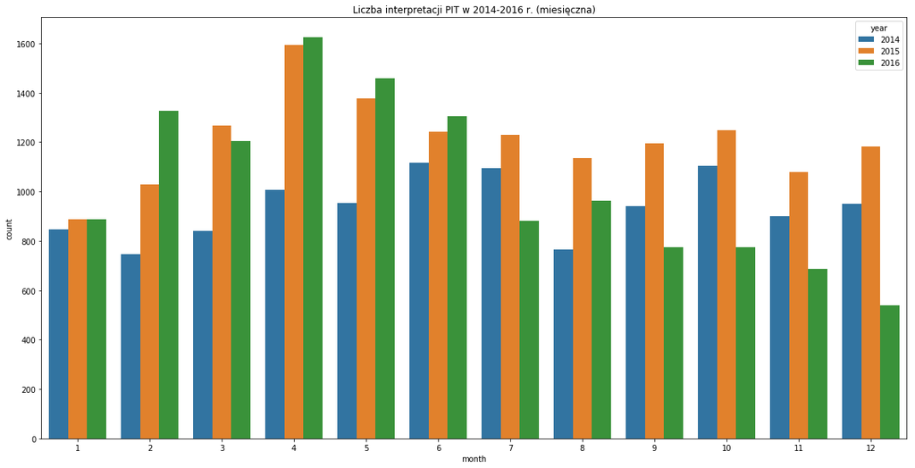

```python
inmemoriam_scripts.present_monthly_data("PIT", "Liczba interpretacji PIT w 2014-2016 r. (miesięczna)")
```

Dnia 15 lipca 2016 r. weszła w życie tak zwana klauzula GAAR (ang. *General anti-avoidance rule*) - czyli klauzula **przeciwko unikaniu opodatkowania**. Zgodnie z art. 119a par. 1 Ordynacji Podatkowej: czynność dokonana przede wszystkim **w celu osiągnięcia korzyści podatkowej**, sprzecznej w danych okolicznościach z przedmiotem i celem przepisu ustawy podatkowej, nie skutkuje osiągnięciem korzyści podatkowej, jeżeli sposób działania był sztuczny (unikanie opodatkowania).

**Czym jest korzyść podatkowa? Czym jest korzyść sprzeczna z przedmiotem i celem przepisu ustawy podatkowej?** Nieco jaśniej się zrobi, gdy odwołamy się do uzasadnienia projektu ustawy wprowadzającej powyższy przepis:

**Obserwowana we wszystkich rozwiniętych gospodarkach rynkowych globalizacja unikania opodatkowania przy wykorzystaniu transgranicznych schematów wymusza zunifikowane zwalczanie unikania opodatkowania**. Dotychczasowe doświadczenia Polski oraz innych krajów wskazują, że same umowy o unikaniu podwójnego opodatkowania nie wystarczają do efektywnego przeciwdziałania unikaniu opodatkowania. Standardem w innych rozwiniętych gospodarczo krajach jest klauzula generalna przeciwko unikaniu opodatkowania (...) [str. 1 Uzasadnienia projektu ustawy wprowadzającej GAAR](http://prawo.sejm.gov.pl/isap.nsf/download.xsp/WDU20160000846/U/D20160846Lj.pdf).

Klauzula GAAR wpisuje sie w szerszy międzynarodowy ruch państw przeciw sytuacjom, w której firmy starają się wykorzystywać luki prawne, żeby wytransferować swoje zyski za granicę w poszukiwaniu niższej stawki podatkowej, bądź za pomocą rodzimych mechanizmów zmniejszyć podatek do zapłaty poprzez różne ulgi i koszty uzyskania przychodów ([dyrektywa ATAD](https://ec.europa.eu/taxation_customs/business/company-tax/anti-tax-avoidance-package/anti-tax-avoidance-directive_en), [konwencja MR](https://en.wikipedia.org/wiki/Multilateral_Convention_to_Implement_Tax_Treaty_Related_Measures_to_Prevent_Base_Erosion_and_Profit_Shifting)).

Scenariusze podatkowe, które pozwalały na tego typu ruchy ze strony podmiotów prywatnych dotyczyły przede wszystkim podatków dochodowych, a nie podatków pośrednich, takich jak VAT (legendarne karuzele VAT-owskie działają na podstawie zupełnie innych mechanizmów).

Jak widzimy, spadek liczby wydawanych interpretacji PIT-owskich z czerwca / lipca 2016 r. co najmniej **koreluje** z wprowadzeniem GAAR. Sprawdźmy, czy ten wniosek powinien być zbieżny również z analogiczną sytuacją w **CIT** - podatku dochodowym, który płacą spółki posiadające osobowość prawną.

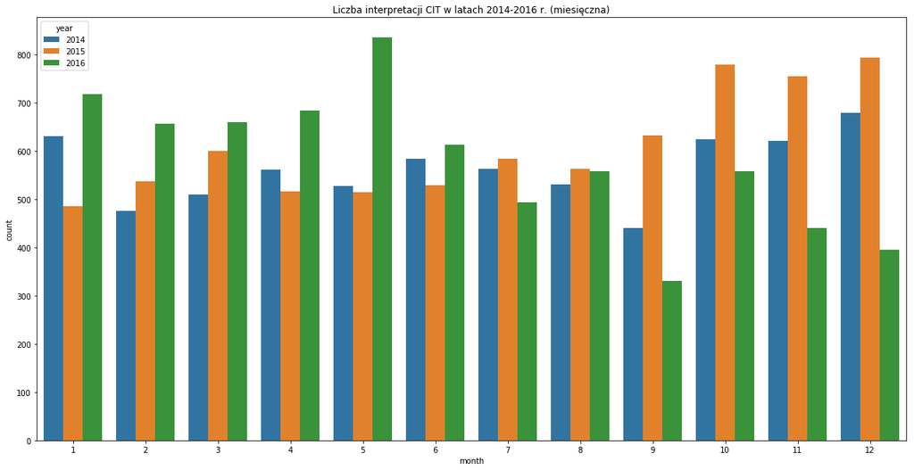

```python
inmemoriam_scripts.present_monthly_data("CIT", "Liczba interpretacji CIT w latach 2014-2016 r. (miesięczna)")
```

Tendencja się potwierdza. Dla porównania VAT (a więc podatek pośredni, który nie jest podatkiem dochodowym):

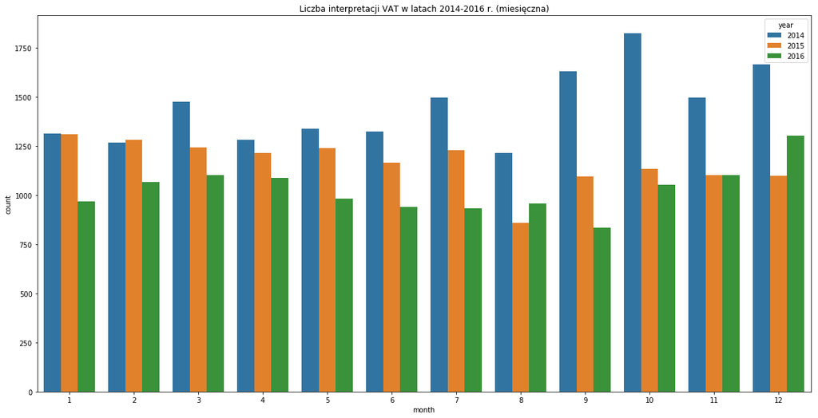

```python
inmemoriam_scripts.present_monthly_data("VAT", "Liczba interpretacji VAT w latach 2014-2016 r. (miesięczna)")
```

Powróćmy jednak do CIT-owskich interpretacji i dokonajmy podobnej analizy semantycznej, jak miało to miejsce w przypadku 2016 r.

## TF-IDF a interpretacje CIT na przestrzeni 2015-2016

Zacznijmy ponownie od stworzenia wykresu punktowego.

```python
data_to_plot = inmemoriam_scripts.read_tax_data_vectorizer_results(
                                            "data/data_2015_CIT.csv",
                                            "data/data_2016_CIT.csv",
                                            "data/data_2017_CIT.csv",
                                            ["2015", "2016", "2017"])
```

```python
data_to_plot_2015_2016 = inmemoriam_scripts.select_two_years_for_comparison("2015",
                                                                            "2016",
                                                                            data_to_plot)

tax_data_for_2015_2016_in_scatterplot = inmemoriam_scripts.TaxDataInScatterPlot(data_to_plot_2015_2016)
tax_data_for_2015_2016_in_scatterplot.get_frequencies()
tax_data_for_2015_2016_in_scatterplot.create_html_with_two_categories("2016", "2015", 'scatter_plots_html/2015_2016_CIT.html')
#tax_data_for_2015_2016_in_scatterplot.take_screenshoot("pics/2015_2016_CIT.png")
```

[figure not shown]

*Najbardziej charakterystyczne słowa dla interpretacji CIT z roku 2015 i 2016 (powyżej)*

Porównanie dostępne [tutaj](https://aleteior.pl/inmemoriam/scatter_plots_html/2015_2016_CIT.html). A poniżej zestawienie f-score dla 2015 i 2016 roku.

```python
tax_data_for_2015_2016_in_scatterplot.present_fscores("2016", "2015")
```

| Najbardziej charakterystyczne słowa dla 2016 r. | fscore |
| --- | --- |
| 2016 | 1 |
| zabezpieczający | 0.978556 |
| 8e | 0.962232 |
| niewłaściwy | 0.957688 |
| przeprowadzić | 0.950749 |
| zależny | 0.948182 |
| sygn | 0.944037 |
| wymian | 0.942931 |
| przejmujący | 0.941558 |
| nominalny | 0.939678 |
| wnieść | 0.937217 |
| wymiana | 0.93522 |
| dzielić | 0.934957 |
| objęcie | 0.934919 |
| częsty | 0.934669 |
| zmniejszyć | 0.933295 |
| lit | 0.933079 |
| nabywać | 0.932904 |
| połączyć | 0.932844 |
| aport | 0.932282 |
| udziać | 0.930988 |
| wnosić | 0.930418 |
| połączenie | 0.930268 |
| ewentualny | 0.929856 |
| przejmować | 0.929855 |
| objąć | 0.926457 |
| niepieniężny | 0.926293 |
| wydzielić | 0.924531 |
| podział | 0.923338 |
| nowa | 0.92245 |

[output cut: 70 more lines]

| Najbardziej charakterystyczne słowa dla 2015 r. | fscore |
| --- | --- |
| 2015 | 0 |
| 2014 | 0.000714345 |
| ska | 0.0102945 |
| brzmieć | 0.0208144 |
| brzmienie | 0.0246295 |
| obrotowy | 0.0247812 |
| posiadający | 0.0283534 |
| zmiana | 0.0323951 |
| obowiązujący | 0.0405259 |
| zysk | 0.0436189 |
| pisemny | 0.0458793 |
| akcyjny | 0.0468319 |
| zadłużenie | 0.0503004 |
| bieżący | 0.0515523 |
| pdop | 0.0525868 |
| obecny | 0.054195 |
| zachować | 0.0542791 |
| przekształcenie | 0.0544621 |
| budynek | 0.0547847 |
| zadłużyć | 0.0554077 |
| dotyczyć | 0.0557698 |
| kapitalizacja | 0.0558807 |
| zarządzanie | 0.056322 |
| niniejszy | 0.0565941 |
| przekształcić | 0.0578091 |
| dobrowolny | 0.0583116 |
| podlegać | 0.0584864 |
| umorzyć | 0.0594606 |
| spółdzielnia | 0.0595901 |
| termin | 0.0597413 |

[output cut: 151 more lines]

Wyodrębniając ponownie charakterystyczne słowa dla interpretacji CIT-owskich możemy lata 2015 oraz 2016 "opisać" następującymi słowami.

**Charakterystyczne słowa w interpretacjach indywidualnych (CIT) w roku 2016**

['zabezpieczający', 'zależny', 'wymian', 'przejmujący', '', 'przeprowadzić', 'nominalny', 'objęcie', 'wymiana', '', 'wnieść', 'nabywać', 'dzielić,', 'aport', 'udziać', 'połączyć', 'przejmować', '', 'połączenie', 'wkład', 'objąć', 'niepieniężny', '', 'zamiana', 'zmniejszyć', 'dokonać', 'podział', '', 'zamian', 'wydać', 'przenieść', 'wydzielić', 'należący', '', 'wydanie', 'zbycie', 'zbyć', 'likwidacja', 'cywilny', '', 'nabycie', 'nabyć', 'neutralny', 'zmniejszenie', '', 'netto', 'korzyść', 'wierzytelność', 'zmniejszeć,', 'uprawniony', 'majątek', 'płatność', 'składnik', '', 'wzajemny', 'wspólnik', 'kapitałowy', 'zorganizować', '', 'otrzymać', 'przejąć', 'udział', 'zapasowy', 'akcja', '', 'zobowiązać', 'organizacyjny', 'początkowy', '', 'zobowiązanie', 'własne', 'rodzaj', 'majątkowy', '', 'osobowy', 'kapitał', 'planować', 'równy', 'realizacja', '', 'wynik', 'podwyższyć', 'fundusz', 'własny']

**Charakterystyczne słowa w interpretacjach indywidualnych (CIT) w roku 2015**

['ska', 'obrotowy', 'zysk', 'akcyjny', 'przekształcenie', '', 'umorzyć', 'zabezpieczyć', 'kapitalizacja', 'zabezpieczenie', '', 'zapłata', 'nieruchomość', 'odsetek', 'kredyt', 'komandytowy', '', 'akcjonariusz', 'pożyczka', 'członek', 'odsetka', 'dać', 'odpis', '', 'zaliczenie', 'udziałowiec', 'zarządzać', 'potrącalny', 'należny', '', 'umowy', 'wynagrodzenie', 'wynagrodzić', 'umowa', 'handlowy', '', 'rynkowy', 'spłata', 'wykonanie', 'uczestnik', 'bankowy', 'bank', '', 'sprzedaż', 'finansowy', 'źródło', 'rachunek', 'amortyzacja', '', 'dywidenda', 'wypłacić', 'saldo', 'klient', 'inwestycja', '', 'zamieszkać', 'wypłat', 'sieć', 'komplementariusz', 'umarzać']

```python
important_tax_words_for_2015_and_2016 = inmemoriam_scripts.ImportantTaxWordsImporter(
                                            "data/words_2015_2016_CIT.pkl")
normalized_data_for_lower_score = TaxDataNormalizer(data_to_plot_2015_2016,
                                                    (important_tax_words_for_2015_and_2016
                                                         .words_lower_fscore),
                                                    "2016",
                                                    "2015").normalize()
(normalized_data_for_lower_score.sort_values(by="zmiana \"charakterystyczności\" danego słowa [w %]",
                                             ascending=True)
                                             .style.applymap(colorize.colorize))
```

|  | 2015 | 2016 | zmiana "charakterystyczności" danego słowa [w %] |
| --- | --- | --- | --- |
| ska | 0.0343309 | 0.0116387 | -66.0985 |
| komplementariusz | 0.0243007 | 0.00910854 | -62.5174 |
| obrotowy | 0.0444426 | 0.0247955 | -44.2079 |
| akcjonariusz | 0.0347386 | 0.022434 | -35.4206 |
| kapitalizacja | 0.0401207 | 0.0278317 | -30.6302 |
| zysk | 0.109109 | 0.0761575 | -30.2003 |
| akcyjny | 0.0658893 | 0.0470608 | -28.5759 |
| przekształcenie | 0.0525972 | 0.0392173 | -25.4384 |
| saldo | 0.0340047 | 0.0258919 | -23.858 |
| kredyt | 0.0435456 | 0.0333137 | -23.4971 |
| wypłacić | 0.0357987 | 0.0278317 | -22.2552 |
| umorzyć | 0.0838294 | 0.0655309 | -21.8283 |
| wypłat | 0.0355541 | 0.0280847 | -21.0086 |
| zabezpieczyć | 0.0591209 | 0.0474825 | -19.6858 |
| klient | 0.0382451 | 0.0312895 | -18.1869 |
| dywidenda | 0.0379189 | 0.0311209 | -17.9279 |
| wykonanie | 0.0405284 | 0.0333137 | -17.8017 |
| udziałowiec | 0.0468075 | 0.0385426 | -17.6571 |
| sieć | 0.0363696 | 0.0300245 | -17.4462 |
| umarzać | 0.0357172 | 0.0295184 | -17.3551 |
| nieruchomość | 0.0991601 | 0.0822299 | -17.0736 |
| zapłata | 0.0783658 | 0.0656996 | -16.163 |
| komandytowy | 0.0757563 | 0.0644345 | -14.9451 |
| pożyczka | 0.0820354 | 0.0699165 | -14.7728 |
| uczestnik | 0.0450135 | 0.0384583 | -14.5627 |
| zabezpieczenie | 0.064503 | 0.0551573 | -14.4888 |
| odsetek | 0.0787735 | 0.0676394 | -14.1344 |
| potrącalny | 0.0499878 | 0.0430969 | -13.7851 |
| odpis | 0.051211 | 0.044362 | -13.3741 |
| spłata | 0.0481122 | 0.0417475 | -13.2289 |
| zaliczenie | 0.0739623 | 0.0641815 | -13.2241 |
| odsetka | 0.0843187 | 0.0733744 | -12.9797 |
| dać | 0.0883144 | 0.0774226 | -12.333 |
| członek | 0.0563484 | 0.049591 | -11.9922 |
| umowy | 0.187067 | 0.164797 | -11.9046 |
| należny | 0.100709 | 0.0890613 | -11.5661 |
| wynagrodzić | 0.101933 | 0.0901577 | -11.5517 |
| wynagrodzenie | 0.102177 | 0.0904107 | -11.5158 |
| umowa | 0.209247 | 0.186725 | -10.7634 |
| zarządzać | 0.0821985 | 0.0733744 | -10.7351 |
| bank | 0.0575716 | 0.0514464 | -10.6392 |
| rynkowy | 0.0895376 | 0.0800371 | -10.6106 |
| handlowy | 0.0890484 | 0.0799528 | -10.2142 |
| źródło | 0.0662154 | 0.0597959 | -9.69493 |
| bankowy | 0.0609149 | 0.055579 | -8.7597 |
| sprzedaż | 0.16089 | 0.147423 | -8.3703 |
| finansowy | 0.128843 | 0.118158 | -8.2929 |
| amortyzacja | 0.0579793 | 0.0533862 | -7.92197 |
| zamieszkać | 0.0477045 | 0.0440246 | -7.71385 |
| inwestycja | 0.0525157 | 0.0485789 | -7.49642 |
| rachunek | 0.083177 | 0.0773383 | -7.01967 |

```python
normalized_data_for_greater_score = TaxDataNormalizer(data_to_plot_2015_2016,
                                                      (important_tax_words_for_2015_and_2016
                                                          .words_greater_fscore),
                                                      "2016",
                                                      "2015").normalize()
(normalized_data_for_greater_score.sort_values(by="zmiana \"charakterystyczności\" danego słowa [w %]",
                                               ascending=False)
                                               .style.applymap(colorize.colorize))
```

|  | 2015 | 2016 | zmiana "charakterystyczności" danego słowa [w %] |
| --- | --- | --- | --- |
| zabezpieczający | 0.00546359 | 0.0345787 | 532.894 |
| przeprowadzić | 0.0202234 | 0.0403981 | 99.7587 |
| zmniejszyć | 0.0187556 | 0.0351691 | 87.5125 |
| zmniejszenie | 0.0193264 | 0.0326389 | 68.8825 |
| zależny | 0.0506401 | 0.0836637 | 65.2121 |
| neutralny | 0.0224252 | 0.0355908 | 58.709 |
| wymian | 0.0428117 | 0.067049 | 56.6137 |
| przejmujący | 0.042404 | 0.0655309 | 54.5395 |
| nominalny | 0.0913316 | 0.138315 | 51.4425 |
| zapasowy | 0.0221805 | 0.0330606 | 49.0524 |
| połączenie | 0.0295197 | 0.0439403 | 48.8508 |
| połączyć | 0.0313953 | 0.0467235 | 48.8233 |
| wnieść | 0.0525157 | 0.0776756 | 47.9094 |
| wymiana | 0.0488461 | 0.0709286 | 45.2082 |
| objęcie | 0.0448504 | 0.0650249 | 44.9818 |
| nabywać | 0.0412623 | 0.0589525 | 42.8725 |
| aport | 0.053005 | 0.0748925 | 41.2933 |
| udziać | 0.0796706 | 0.111242 | 39.6279 |
| przejmować | 0.0487646 | 0.0674707 | 38.3601 |
| wydzielić | 0.0333524 | 0.0461331 | 38.3203 |
| objąć | 0.0605888 | 0.0813022 | 34.1869 |
| niepieniężny | 0.0791813 | 0.106098 | 33.9934 |
| podział | 0.0469706 | 0.061567 | 31.0757 |
| dokonać | 0.0394683 | 0.0515307 | 30.5623 |
| przenieść | 0.038082 | 0.049591 | 30.2214 |
| cywilny | 0.0349017 | 0.0452897 | 29.7635 |
| wkład | 0.0540651 | 0.0700008 | 29.4752 |
| zamiana | 0.0508032 | 0.0654466 | 28.8236 |
| zamian | 0.0507217 | 0.0647719 | 27.7005 |
| przejąć | 0.0308244 | 0.03888 | 26.1337 |
| wzajemny | 0.0340863 | 0.0426752 | 25.1976 |
| należący | 0.0753486 | 0.0933626 | 23.9075 |
| wydać | 0.146131 | 0.180653 | 23.6242 |
| likwidacja | 0.0441164 | 0.0541452 | 22.7325 |
| wydanie | 0.0475414 | 0.0576874 | 21.3415 |
| zbyć | 0.11074 | 0.133423 | 20.4838 |
| zbycie | 0.110169 | 0.132074 | 19.8832 |
| nabycie | 0.116692 | 0.135447 | 16.0721 |
| korzyść | 0.0552883 | 0.0639285 | 15.6276 |
| składnik | 0.0578977 | 0.0668803 | 15.5146 |
| zorganizować | 0.042404 | 0.0488319 | 15.1588 |
| wierzytelność | 0.0985077 | 0.113351 | 15.0679 |
| majątek | 0.141075 | 0.162267 | 15.022 |
| podwyższyć | 0.0378374 | 0.0435186 | 15.0148 |
| netto | 0.0678464 | 0.0778443 | 14.7362 |
| nabyć | 0.147191 | 0.167833 | 14.0244 |
| równy | 0.0377559 | 0.0427596 | 13.2528 |
| uprawniony | 0.0612411 | 0.0691575 | 12.9265 |
| kapitałowy | 0.137079 | 0.152399 | 11.1763 |
| płatność | 0.0659708 | 0.0732057 | 10.9668 |
| wspólnik | 0.124113 | 0.137134 | 10.4912 |
| otrzymać | 0.126886 | 0.137893 | 8.67511 |
| udział | 0.193917 | 0.209412 | 7.9908 |
| akcja | 0.159667 | 0.171038 | 7.12163 |
| organizacyjny | 0.0497431 | 0.0532175 | 6.98464 |
| własne | 0.0718421 | 0.0767479 | 6.82856 |
| zobowiązać | 0.0952459 | 0.100953 | 5.99203 |
| planować | 0.0421593 | 0.044362 | 5.22456 |
| zobowiązanie | 0.0826878 | 0.0857721 | 3.73013 |
| początkowy | 0.0591209 | 0.061061 | 3.28148 |
| osobowy | 0.0894561 | 0.0913384 | 2.10423 |
| fundusz | 0.0694773 | 0.0708442 | 1.96746 |
| realizacja | 0.0737177 | 0.0748081 | 1.47921 |
| majątkowy | 0.125663 | 0.127098 | 1.14223 |
| kapitał | 0.102993 | 0.103989 | 0.967507 |
| wynik | 0.133165 | 0.134182 | 0.764117 |
| własny | 0.117589 | 0.116556 | -0.879225 |

Jak widać, pewne wyrazy dotyczące M&A ("aport", "kapitałowy", "podwyższyć [kapitał]") **są bardziej charakterystyczne dla 2016 r. niż dla 2015 r.** Prawdopodobnie GAAR nie przestraszył aż tak CIT-owców. Widzieliśmy jednak tendencje spadkową dla roku 2017 - zobaczmy jak ten rok różni się od roku 2016.

## TF-IDF a interpretacje CIT na przestrzeni 2016-2017

Znowu zaczynamy od "scatter plota":

```python
data_to_plot_2016_2017 = inmemoriam_scripts.select_two_years_for_comparison("2016",
                                                                            "2017",
                                                                            data_to_plot)

tax_data_for_2016_2017_in_scatterplot = inmemoriam_scripts.TaxDataInScatterPlot(data_to_plot_2016_2017)
tax_data_for_2016_2017_in_scatterplot.get_frequencies()
tax_data_for_2016_2017_in_scatterplot.create_html_with_two_categories("2017", "2016", 'scatter_plots_html/2016_2017_CIT.html')
#tax_data_for_2016_2017_in_scatterplot.take_screenshoot("pics/2016_2017_CIT.png")
```

[figure not shown]

*Najbardziej charakterystyczne słowa dla interpretacji z roku 2016 i 2017 (powyżej)*

Dla roku 2017 ([tutaj wersja interaktywna](https://aleteior.pl/inmemoriam/scatter_plots_html/2016_2017_CIT.html)) bardziej charakterystyczne są interpretacje dotyczace badań i rozwoju. Może mieć to związek z promowaną przez rząd **ulgą badawczo-rozwojową**, wprowadzoną w 2016 r. (w 2017 r. stała się bardziej korzystna). Równolegle można zauważyć totalny odwrót od interpretacji dotyczących M&A. Poniższe tabele wspierają takie wnioski.

```python
tax_data_for_2016_2017_in_scatterplot.present_fscores("2017", "2016")
```

| Najbardziej charakterystyczne słowa dla 2017 r. | fscore |
| --- | --- |
| krajowy | 1 |
| 2017 | 0.99286 |
| informacja | 0.992086 |
| badawczy | 0.969274 |
| badać | 0.964966 |
| imię | 0.963717 |
| prace | 0.963195 |
| 18d | 0.9619 |
| rozwojowy | 0.958193 |
| projekt | 0.955244 |
| badanie | 0.954532 |
| wezwanie | 0.948745 |
| technologia | 0.946514 |
| wiedza | 0.943422 |
| 000 | 0.937335 |
| umiejętność | 0.933919 |
| stan | 0.933475 |
| składka | 0.930992 |
| statut | 0.929991 |
| produkt | 0.927973 |
| ulga | 0.926287 |
| kwalifikować | 0.925136 |
| kwalifikowany | 0.921671 |
| mały | 0.920872 |
| pilotażowy | 0.918015 |
| wskazać | 0.910288 |
| naukowy | 0.906775 |
| techniczny | 0.90653 |
| społeczny | 0.905189 |
| euro | 0.90504 |
| rozwój | 0.901804 |
| kalendarzowy | 0.901344 |
| praca | 0.900249 |

| Najbardziej charakterystyczne słowa dla 2016 r. | fscore |
| --- | --- |
| 8e | 0 |
| wymian | 0.00143463 |
| wymiana | 0.00604978 |
| niewłaściwy | 0.00711433 |
| zamian | 0.00866401 |
| zamiana | 0.00921436 |
| nabywać | 0.0140206 |
| poznań | 0.0156218 |
| poznanie | 0.0159393 |
| wnieść | 0.0168298 |
| udziać | 0.0187109 |
| aport | 0.0209665 |
| nominalny | 0.0212735 |
| niepieniężny | 0.0234793 |
| odpłatny | 0.0245131 |
| objęcie | 0.0249156 |
| warszawa | 0.0272319 |
| zbyć | 0.0280981 |
| zbycie | 0.0287067 |
| stanowisko | 0.029955 |
| zależny | 0.0299856 |
| 12 | 0.0299884 |
| akcja | 0.030429 |
| odpowiadać | 0.0305583 |
| wkład | 0.0315304 |
| zabezpieczający | 0.0318114 |
| wspólnik | 0.0328723 |
| objąć | 0.0329496 |
| udział | 0.0330179 |
| uczestnictwo | 0.0338863 |

[output cut: 285 more lines]

Doszło do ogromnej redukcji słów związanych z M&A (transakcjami połączeniowymi spółek). **Natomiast nagle nasi "CIT-owcy" stali się bardzo innowacyjni**. Podatnicy (a może doradcy podatkowi) nie znają pojęcia próżni.

**Charakterystyczne słowa w interpretacjach indywidualnych w roku 2017**

['badawczy', 'prace', 'projekt', 'badać', 'rozwojowy', '18d', 'badanie', 'technologia', 'wiedza', 'umiejętność', 'kwalifikować', 'produkt', 'kwalifikowany', 'ulga', 'statut', 'naukowy', 'pilotażowy', 'techniczny', 'społeczny', 'praca', 'rozumienie', 'sieć']

**Charakterystyczne słowa w interpretacjach indywidualnych w roku 2016**

['wymian', '8e', 'wymiana', 'niewłaściwy', 'zamian', 'zamiana', 'nabywać', 'wnieść', 'udziać', 'nominalny', 'aport', 'odpłatny', 'niepieniężny', 'objęcie', 'zbyć', 'zbycie', 'zależny', 'akcja', 'wspólnik', 'wkład', 'udział', 'należący', 'objąć', 'zakładowy', 'nabycie', 'nabyć', 'własne', '16', 'wartościowy', 'wynik', 'umorzyć', 'likwidacja', 'korzyść', 'rynkowy', 'kapitałowy', 'własny', 'zabezpieczający', 'kapitał', 'podwyższyć', 'fundusz', 'pieniężny', 'dzielić', 'zysk', 'uczestnik', 'majątek', 'wnosić', 'przekształcić', 'ilość', 'komandytowy', 'transakcja', 'własność', 'powstać', 'całość', 'inwestycyjny', 'udziałowiec', 'wspólny', 'nieodpłatny', 'równy', 'odsetka', 'wypłata', 'przekształcenie', 'odsetek', 'przejmujący', 'przysporzyć', 'składnik', 'uzyskać', 'należeć', 'neutralny', 'środki', 'zmniejszyć', 'spółka', 'początkowy', 'proporcja', 'akcyjny', 'wydatek', 'wydzielić', 'sprzedaż', 'środek', 'członkowski', 'państwo', 'wynagrodzić', 'wynagrodzenie', 'członek', 'finansowy', 'niezależny', 'niematerialny', 'zorganizować', 'spółdzielnia', 'ponieść', 'przedsiębiorstwo', 'odrębny', 'naczelny', 'przenieść', 'wchodzący', 'bank', 'polskie', 'handlowy', 'usługi', 'zagraniczny', 'zmniejszenie', 'koszt', 'kapitała', 'przepis', 'pożyczka', 'ewidencja', 'ekonomiczny', 'wierzytelność', 'amortyzacja', 'unia', 'planować', 'rachunek', 'usługa', 'zmniejszeć', 'oznaczony', 'zobowiązany', 'cywilny', 'obniżyć', 'wyemitować', 'trwała', 'połączenie', 'obniżenie', 'zapasowy', 'amortyzacyjny', 'publiczny', 'następować', 'dobrowolny', 'wczesny', 'część', 'zamieszkać', 'bankowy', 'grunt', 'trwały', 'świadczenie', 'przejąć', 'siedziba', 'towarowy', 'nieprawidłowy', 'konsekwencja', 'zarządzać', 'podziać', 'świadczyć', 'obowiązek', 'dodatni', 'posiadający', 'umowa', 'umowy', 'zobowiązać', 'cel', 'odpis', 'stosunek', 'gospodarczy', 'bezpośredni', 'faktura']

```python
important_tax_words_for_2016_and_2017 = inmemoriam_scripts.ImportantTaxWordsImporter("data/words_2016_2017_CIT.pkl")
normalized_data_for_lower_score = TaxDataNormalizer(data_to_plot_2016_2017,
                                                    (important_tax_words_for_2016_and_2017
                                                        .words_lower_fscore),
                                                    "2017",
                                                    "2016").normalize()
(normalized_data_for_lower_score.sort_values(by="zmiana \"charakterystyczności\" danego słowa [w %]",
                                            ascending=True)
                                            .style.applymap(colorize.colorize))
```

|  | 2016 | 2017 | zmiana "charakterystyczności" danego słowa [w %] |
| --- | --- | --- | --- |
| 8e | 0.0551573 | 0.00165476 | -96.9999 |
| zabezpieczający | 0.0345787 | 0.00156767 | -95.4664 |
| wymian | 0.067049 | 0.00357081 | -94.6743 |
| wymiana | 0.0709286 | 0.00635778 | -91.0364 |
| niewłaściwy | 0.0570971 | 0.00513848 | -91.0005 |
| zamian | 0.0647719 | 0.00696743 | -89.2431 |
| zamiana | 0.0654466 | 0.0073158 | -88.8217 |
| nabywać | 0.0589525 | 0.00836091 | -85.8175 |
| wnosić | 0.0345787 | 0.00539976 | -84.3842 |
| wnieść | 0.0776756 | 0.0128897 | -83.4057 |
| wyemitować | 0.0287594 | 0.00479011 | -83.3442 |
| udziać | 0.111242 | 0.0198572 | -82.1496 |
| aport | 0.0748925 | 0.0144574 | -80.6958 |
| nominalny | 0.138315 | 0.0269988 | -80.4802 |
| obniżenie | 0.0290124 | 0.00574813 | -80.1873 |
| wczesny | 0.0312052 | 0.00618359 | -80.1841 |
| niepieniężny | 0.106098 | 0.0222087 | -79.0677 |
| odpłatny | 0.113772 | 0.0245602 | -78.4129 |
| objęcie | 0.0650249 | 0.014109 | -78.3021 |
| dobrowolny | 0.0297714 | 0.00679324 | -77.182 |
| obniżyć | 0.0306148 | 0.00722871 | -76.3882 |
| zbyć | 0.133423 | 0.0317889 | -76.1744 |
| zbycie | 0.132074 | 0.0319631 | -75.7991 |
| zależny | 0.0836637 | 0.0209023 | -75.0163 |
| akcja | 0.171038 | 0.043198 | -74.7436 |
| wkład | 0.0700008 | 0.0181153 | -74.1213 |
| uczestnik | 0.0384583 | 0.010277 | -73.2777 |
| wspólnik | 0.137134 | 0.0366661 | -73.2626 |
| objąć | 0.0813022 | 0.0217732 | -73.2194 |
| udział | 0.209412 | 0.0561749 | -73.175 |

[output cut: 123 more lines]

```python
normalized_data_for_greater_score = TaxDataNormalizer(data_to_plot_2016_2017,
                                                      (important_tax_words_for_2016_and_2017
                                                          .words_greater_fscore),
                                                      "2017",
                                                      "2016").normalize()
(normalized_data_for_greater_score.sort_values(by="zmiana \"charakterystyczności\" danego słowa [w %]",
                                              ascending=False)
                                              .style.applymap(colorize.colorize))
```

|  | 2016 | 2017 | zmiana "charakterystyczności" danego słowa [w %] |
| --- | --- | --- | --- |
| pilotażowy | 0.00303618 | 0.0129768 | 327.406 |
| 18d | 0.00514464 | 0.0169831 | 230.113 |
| wiedza | 0.00801214 | 0.0169831 | 111.967 |
| badawczy | 0.0108796 | 0.0222087 | 104.13 |
| badać | 0.010711 | 0.0213377 | 99.2139 |
| umiejętność | 0.00969891 | 0.0171573 | 76.8991 |
| badanie | 0.011976 | 0.0209023 | 74.5341 |
| technologia | 0.011217 | 0.0193346 | 72.3688 |
| ulga | 0.00969891 | 0.0165476 | 70.6134 |
| rozwojowy | 0.0135785 | 0.0229054 | 68.6891 |
| prace | 0.016446 | 0.0272601 | 65.7551 |
| statut | 0.0113013 | 0.0177669 | 57.2109 |
| projekt | 0.016699 | 0.0256053 | 53.3343 |
| produkt | 0.0199882 | 0.0237763 | 18.952 |
| kwalifikować | 0.0261449 | 0.0290019 | 10.9277 |
| kwalifikowany | 0.0313739 | 0.0335307 | 6.87474 |
| techniczny | 0.0236147 | 0.0235151 | -0.422089 |
| społeczny | 0.0247955 | 0.0242118 | -2.35394 |
| naukowy | 0.0291811 | 0.0280439 | -3.89698 |
| sieć | 0.0300245 | 0.0273472 | -8.91708 |
| praca | 0.0478199 | 0.0432851 | -9.48291 |
| rozumienie | 0.0434343 | 0.0373628 | -13.9784 |

## Lewiatan pożera własne dzieci

Jedna zmiana i duże implikacje. Czy rzeczywiście gros wydawanych interpretacji do połowy roku 2016 dotyczył osiągania samych *"korzyści podatkowych, sprzecznych z przedmiotem i celem przepisów ustawy podatkowej"*? Czy GAAR odstraszył podatników, ponieważ obawiali się, że skrupulatny fiskus uzna **każdą oszczędność podatkową za próbę uniknięcia opodatkowania**? Czy twórcy regulacji prognozowali aż tak duży spadek liczby wydawanych interpretacji podatkowych?...

**Czy ustawodawca w ogóle bada długofalowe skutki swoich działań?** Oczywiście, że tak:

[figure not shown]

*Polski ustawodawca tłumaczący skutki swoich działań* (rekonstrukcja)

Na aleteior.pl wkrótce przedstawię, w którym kierunku zmierzają interpretacje w 2018 r.

Tymczasem zobaczcie, jak wygląda innowacyjny Lewiatan roku 2017:

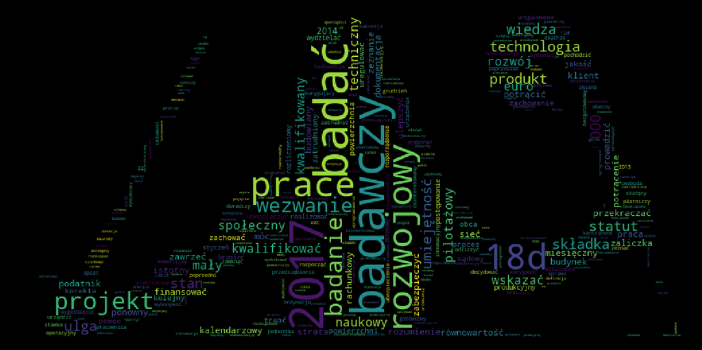

```
<inmemoriam_scripts.WordCloudMaker.WordCloudMaker at 0x7ff0f5edbac8>
```

```python
from inmemoriam_scripts import WordCloudMaker

data_to_pic = tax_data_for_2016_2017_in_scatterplot.data_fscores
data_to_pic = (data_to_pic*10000)["fscore"].apply(int)
data_to_pic = data_to_pic.drop(["krajowy", "informacja", "imię"])

WordCloudMaker.WordCloudMaker(data_to_pic,
                              'pics/lewiatan.png',
                              'pics/crazy_leviathan.png')
```

## Źródła

1. http://scikit-learn.org/stable/modules/feature_extraction.html#text-feature-extraction
2. https://github.com/JasonKessler/scattertext
3. https://en.wikipedia.org/wiki/F1_score
4. http://prawo.sejm.gov.pl/isap.nsf/download.xsp/WDU20160000846/U/D20160846Lj.pdf
5. https://github.com/amueller/word_cloud